# A Brief Appendix on Practical Statistics

Hugo Bowne-Anderson, Yale University, Molecular Biophysics & Biochemistry

05 November, 2015

This appendix contains assorted supporting material for the ‘Practical Statistics for Experimentalists’ Workshop.

# 1 A Compendium of Distributions

This section contains a variety of distributions that were discussed in the Workshop.

## 1.1 Normal (Gaussian) Distribution

**Motivation**:

- The Central Limit Theorem: see Workshop I for details.
- Things in the phenomenal world are often normally distributed (this is why the term ‘bell curve’ is part of our general society’s lexicon, rather than merely a technical term);
- Measurement error (e.g. using a ruler) is often normally distributed.

**Equation**: $P(x) = \frac{1}{\sigma\sqrt{2\pi}}\text{exp}(-\frac{(x - \mu)^2}{2\sigma^2})$

**Examples**:

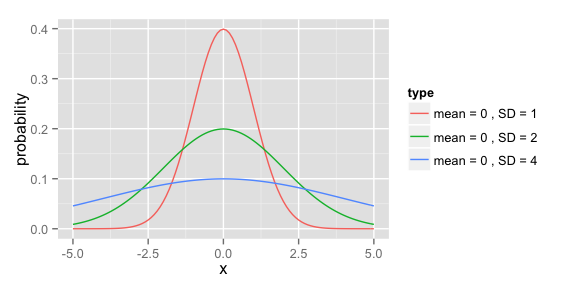

## 1.2 Binomial Distribution

**Motivation**:

- Flipping coins: see Workshop III for details.
- Situations with a binary outcome, e.g. survival or death of a mutant.

**Equation**: $P(k|n) = {n\choose k}p^k(1 - p)^{n-k}$, where $p$ is the binomial probability (the probability of flipping heads).

**Example**:

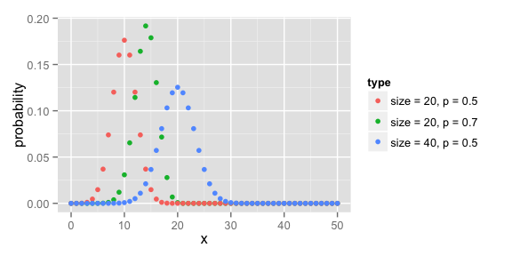

## 1.3 Poisson Distribution

**Motivation**:

- Poisson distributions are commonly used when counting discrete events, such as counting photons in optical devices. A Poisson distribution describes the probability of a given number of events occurring in a fixed interval of time, in the case that these events occur with a known average rate $\lambda$ and are independent of one another.

**Example**: ‘The classic Poisson example is the data set of von Bortkiewicz (1898), for the chance of a Prussian cavalryman being killed by the kick of a horse.’ See [here](https://www.umass.edu/wsp/resources/poisson/) for more.

**Equation**: $P(k) = \frac{\lambda^k}{k!}e^{-\lambda}$, for $k \in \{0,1,2,3,\ldots\}$.

**Example**:

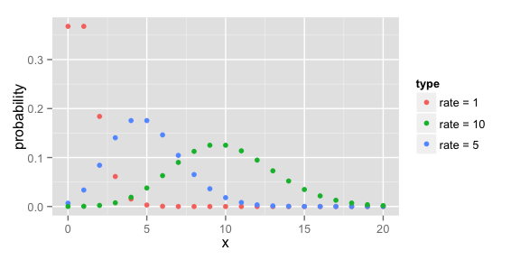

## 1.4 Exponential Distribution

**Motivation**:

- Radioactive decay;
- Any [Poisson Process](https://en.wikipedia.org/wiki/Poisson_process) has exponentially distributed waiting times.

**Equation**: $P(x) = \frac{\text{exp}(-x/\mu)}{\mu}$.

**Example**:

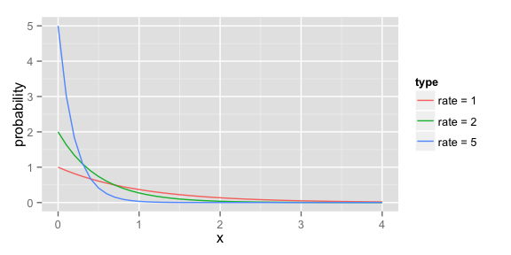

## 1.5 Gamma Distribution

**Motivation**:

- Results from multistep processes (and thus generalizes the exponential distribution).

**Note**: For multistep processes, also see the [Weibull](https://en.wikipedia.org/wiki/Weibull_distribution) & [Erlang](https://en.wikipedia.org/wiki/Erlang_distribution) distributions.

**Equation**: $P(x) = \frac{\beta^{\alpha}}{\Gamma(\alpha)}x^{\alpha - 1}e^{-\beta x}$.

**Example**:

[figure not shown]

# 2 Statistical Hypothesis Testing

## 2.1 Definition of the F-statistic

The following is primarily from Rice, Ch. 12 (see references below): let’s say that we have $I$ groups, each with $J$ samples, and let $Y_{ij}=$ the $j$ observation in the $i$th group. The statistical model is

$Y_{ij} = \mu + \alpha_{i} + \varepsilon_{ij}.$ Assumption: $\varepsilon_{ij}$ are i.i.d Gaussian; we also normalize such that $\sum\alpha_i = 0$. Then $SS_{TOT} = SS_{W} + SS_{B},$

where $SS_{TOT} = \sum\limits_{ij}(Y_{ij}-\bar{Y}_{..})^2$ is the total sum of squares of the data, $SS_{W}=\sum\limits_{ij}(Y_{ij}-\bar{Y}_{i.})^2$ is the sum of squares within groups (unexplained variance) & $SS_{B}=\sum\limits_{i}(\bar{Y}_{i.}-\bar{Y}_{..})^2$ is the sum of squares between groups (explained variance). We look at the F-statistic

$F = \frac{SS_{B}/(I-1)}{SS_{W}/I(J-1)}$

and use it to test the null hypothesis $H_0: \alpha_1 = \alpha_2 = \ldots = \alpha_I = 0,$ which will be distributed with $(I-1)$ and $I(J-1)$ degrees of freedom. The **p-value** is defined as the probability of seeing an F-statistic $\geq$ the one encountered, under the assumption of the null hypothesis.

**Problem**: if the null hypothesis is rejected, we do not know which $\alpha_i$’s are different from each other. There are *post hoc* methods to deal with this that we shall not delve into here. Suffice to say, this is an interesting & important field of statistics & experimental design known as [*post hoc analysis*](https://en.wikipedia.org/wiki/Post_hoc_analysis).

# 3 Maximum likelihood estimation

## 3.1 For the binomial probability (details of calculation)

Assume that we flip a (possibly biased) coin $n$ times and see $k$ heads. The likelihood function of seeing this data $D$ is given by

$\mathcal{L}(p | k \text{ heads}) := P(k \text{ heads }| n \text{ tosses }, p) = {n\choose k}p^k(1 - p)^{n-k}.$

The **maximum likelihood estimate** is the value $\hat{p}$ of $p$ that *maximizes* this *likelihood* function. As the log function is monotonically increasing, $\hat{p}$ also maximizes the log likelihood, denoted $\mathcal{LL}$. Remembering our log laws, we see that

$\mathcal{LL} = \text{log}{n\choose k} + k\text{log}p + (n-k)\text{log}(1-p).$

To find the maximum, we solve for $\frac{d\mathcal{LL}}{dp}\bigg|_{\hat{p}} = 0$:

$\frac{k}{\hat{p}} - \frac{n-k}{1-\hat{p}} = 0,$

and it follows that $k(1-\hat{p}) = (n-k)\hat{p}$. Then $\hat{p}=k/n$ is a stationary point. To show that it is actually a maximum (as opposed to a minimum or a point of inflection), you also need to prove that $\frac{d^2\mathcal{LL}}{dp^2}\bigg|_{\hat{p}} < 0$ (exercise for the reader!).

## 3.2 Ordinary least squares as MLE

We have data $D=\{x_i , y_i\}_i$. Make the assumption that each $y_i = ax_i + b + \varepsilon_i$ where $a$ and $b$ are real numbers and the $\varepsilon_i$ are drawn independently from $N(0,\sigma^2)$, the Gaussian distribution with mean $0$ and variance $\sigma^2$:

$P(\varepsilon_i) = \frac{1}{\sigma\sqrt{(2\pi)}}\text{exp}(-\frac{\varepsilon_i}{2\sigma^2}).$

**What are the maximum likelihood estimates $\hat{a},\hat{b}$?**

The likelihood function is

$\mathcal{L}(a,b|D) = \prod_i P(x_i,y_i|a,b \propto \prod_i\text{exp}\bigg(\frac{(f(x_i)-y_i)^2}{2\sigma^2}\bigg)$

Recall that to maximize the *likelihood*, we can *minimize* the *negative log likelihood*:

$-\mathcal{LL}=-\text{log}\bigg(\prod_i\text{exp}\bigg(\frac{(f(x_i)-y_i)^2}{2\sigma^2}\bigg)\bigg)=\frac{1}{2\sigma^2}\sum_i(f(x_i)-y_i)^2.$

This is precisely what we minimize to perform linear regression using ordinary least squares!

# 4 References

- *Data Reduction and Error Analysis for the Physical Sciences* by Philip Bevington & D. Keith Robinson (2002), *McGraw-Hill Education*.
- *Mathematical Statistics and Data Analysis* by John A. Rice (1988), *Duxbury Press*;